# Risk Factor Analysis

## Outcome Variable

**Outcome Variable:** ever_swasted

## Predictor Variables

**Intervention Variable:** brthmon

**Adjustment Set:**

unadjusted

## Stratifying Variables

The analysis was stratified on these variable(s):

- agecat
- studyid
- country

## Data Summary

| agecat | studyid | country | brthmon | ever_swasted | n_cell | n |
| --- | --- | --- | --- | --- | --- | --- |
| 0-24 months | CMC-V-BCS-2002 | INDIA | 1 | 0 | 28 | 373 |
| 0-24 months | CMC-V-BCS-2002 | INDIA | 1 | 1 | 6 | 373 |
| 0-24 months | CMC-V-BCS-2002 | INDIA | 2 | 0 | 14 | 373 |
| 0-24 months | CMC-V-BCS-2002 | INDIA | 2 | 1 | 2 | 373 |
| 0-24 months | CMC-V-BCS-2002 | INDIA | 3 | 0 | 23 | 373 |
| 0-24 months | CMC-V-BCS-2002 | INDIA | 3 | 1 | 8 | 373 |
| 0-24 months | CMC-V-BCS-2002 | INDIA | 4 | 0 | 32 | 373 |
| 0-24 months | CMC-V-BCS-2002 | INDIA | 4 | 1 | 12 | 373 |
| 0-24 months | CMC-V-BCS-2002 | INDIA | 5 | 0 | 25 | 373 |
| 0-24 months | CMC-V-BCS-2002 | INDIA | 5 | 1 | 11 | 373 |
| 0-24 months | CMC-V-BCS-2002 | INDIA | 6 | 0 | 30 | 373 |
| 0-24 months | CMC-V-BCS-2002 | INDIA | 6 | 1 | 7 | 373 |
| 0-24 months | CMC-V-BCS-2002 | INDIA | 7 | 0 | 30 | 373 |
| 0-24 months | CMC-V-BCS-2002 | INDIA | 7 | 1 | 9 | 373 |
| 0-24 months | CMC-V-BCS-2002 | INDIA | 8 | 0 | 9 | 373 |
| 0-24 months | CMC-V-BCS-2002 | INDIA | 8 | 1 | 9 | 373 |
| 0-24 months | CMC-V-BCS-2002 | INDIA | 9 | 0 | 15 | 373 |
| 0-24 months | CMC-V-BCS-2002 | INDIA | 9 | 1 | 6 | 373 |
| 0-24 months | CMC-V-BCS-2002 | INDIA | 10 | 0 | 21 | 373 |
| 0-24 months | CMC-V-BCS-2002 | INDIA | 10 | 1 | 8 | 373 |
| 0-24 months | CMC-V-BCS-2002 | INDIA | 11 | 0 | 34 | 373 |
| 0-24 months | CMC-V-BCS-2002 | INDIA | 11 | 1 | 9 | 373 |
| 0-24 months | CMC-V-BCS-2002 | INDIA | 12 | 0 | 20 | 373 |
| 0-24 months | CMC-V-BCS-2002 | INDIA | 12 | 1 | 5 | 373 |
| 0-24 months | CMIN | BANGLADESH | 1 | 0 | 24 | 272 |
| 0-24 months | CMIN | BANGLADESH | 1 | 1 | 4 | 272 |
| 0-24 months | CMIN | BANGLADESH | 2 | 0 | 26 | 272 |
| 0-24 months | CMIN | BANGLADESH | 2 | 1 | 1 | 272 |
| 0-24 months | CMIN | BANGLADESH | 3 | 0 | 17 | 272 |
| 0-24 months | CMIN | BANGLADESH | 3 | 1 | 3 | 272 |

[output cut: 618 more lines]

The following strata were considered:

- agecat: 0-24 months, studyid: CMC-V-BCS-2002, country: INDIA
- agecat: 0-24 months, studyid: CMIN, country: BANGLADESH
- agecat: 0-24 months, studyid: CONTENT, country: PERU
- agecat: 0-24 months, studyid: EE, country: PAKISTAN
- agecat: 0-24 months, studyid: GMS-Nepal, country: NEPAL
- agecat: 0-24 months, studyid: Guatemala BSC, country: GUATEMALA
- agecat: 0-24 months, studyid: iLiNS-Zinc, country: BURKINA FASO
- agecat: 0-24 months, studyid: IRC, country: INDIA
- agecat: 0-24 months, studyid: JiVitA-3, country: BANGLADESH
- agecat: 0-24 months, studyid: JiVitA-4, country: BANGLADESH
- agecat: 0-24 months, studyid: Keneba, country: GAMBIA
- agecat: 0-24 months, studyid: LCNI-5, country: MALAWI
- agecat: 0-24 months, studyid: MAL-ED, country: BANGLADESH
- agecat: 0-24 months, studyid: MAL-ED, country: BRAZIL
- agecat: 0-24 months, studyid: MAL-ED, country: INDIA
- agecat: 0-24 months, studyid: MAL-ED, country: NEPAL
- agecat: 0-24 months, studyid: MAL-ED, country: PERU
- agecat: 0-24 months, studyid: MAL-ED, country: SOUTH AFRICA
- agecat: 0-24 months, studyid: MAL-ED, country: TANZANIA, UNITED REPUBLIC OF
- agecat: 0-24 months, studyid: NIH-Birth, country: BANGLADESH
- agecat: 0-24 months, studyid: PROBIT, country: BELARUS
- agecat: 0-24 months, studyid: PROVIDE, country: BANGLADESH
- agecat: 0-24 months, studyid: ResPak, country: PAKISTAN
- agecat: 0-24 months, studyid: SAS-CompFeed, country: INDIA
- agecat: 0-24 months, studyid: SAS-FoodSuppl, country: INDIA
- agecat: 0-24 months, studyid: TanzaniaChild2, country: TANZANIA, UNITED REPUBLIC OF
- agecat: 0-24 months, studyid: ZVITAMBO, country: ZIMBABWE

### Dropped Strata

Some strata were dropped due to rare outcomes:

- agecat: 0-24 months, studyid: CMC-V-BCS-2002, country: INDIA
- agecat: 0-24 months, studyid: CMIN, country: BANGLADESH
- agecat: 0-24 months, studyid: CONTENT, country: PERU
- agecat: 0-24 months, studyid: EE, country: PAKISTAN
- agecat: 0-24 months, studyid: GMS-Nepal, country: NEPAL
- agecat: 0-24 months, studyid: Guatemala BSC, country: GUATEMALA
- agecat: 0-24 months, studyid: IRC, country: INDIA
- agecat: 0-24 months, studyid: JiVitA-4, country: BANGLADESH
- agecat: 0-24 months, studyid: LCNI-5, country: MALAWI
- agecat: 0-24 months, studyid: MAL-ED, country: BANGLADESH
- agecat: 0-24 months, studyid: MAL-ED, country: BRAZIL
- agecat: 0-24 months, studyid: MAL-ED, country: INDIA
- agecat: 0-24 months, studyid: MAL-ED, country: NEPAL
- agecat: 0-24 months, studyid: MAL-ED, country: PERU
- agecat: 0-24 months, studyid: MAL-ED, country: SOUTH AFRICA
- agecat: 0-24 months, studyid: MAL-ED, country: TANZANIA, UNITED REPUBLIC OF
- agecat: 0-24 months, studyid: NIH-Birth, country: BANGLADESH
- agecat: 0-24 months, studyid: PROVIDE, country: BANGLADESH
- agecat: 0-24 months, studyid: ResPak, country: PAKISTAN
- agecat: 0-24 months, studyid: SAS-FoodSuppl, country: INDIA

## Methods Detail

We're interested in the causal parameters $E[Y_a]$ for all values of $a \in \mathcal{A}$. These parameters represent the mean outcome if, possibly contrary to fact, we intervened to set all units to have $A=a$. Under the randomization and positivity assumptions, these are identified by the statistical parameters $\psi_a=E_W[E_{Y|A,W}(Y|A=a,W)]$. In addition, we're interested in the mean of $Y$, $E[Y]$ under no intervention (the observed mean). We will estimate these parameters by using SuperLearner to fit the relevant likelihood factors -- $E_{Y|A,W}(Y|A=a,W)$ and $p(A=a|W)$, and then updating our likelihood fit using a joint TMLE.

For unadjusted analyses ($W=\{\}$), initial likelihoods were estimated using Lrnr_glm to estimate the simple $E(Y|A)$ and Lrnr_mean to estimate $p(A)$. For adjusted analyses, a small library containing Lrnr_glmnet, Lrnr_xgboost, and Lrnr_mean was used.

Having estimated these parameters, we will then use the delta method to estimate relative risks and attributable risks relative to a prespecified baseline level of $A$.

# Results Detail

## Results Plots

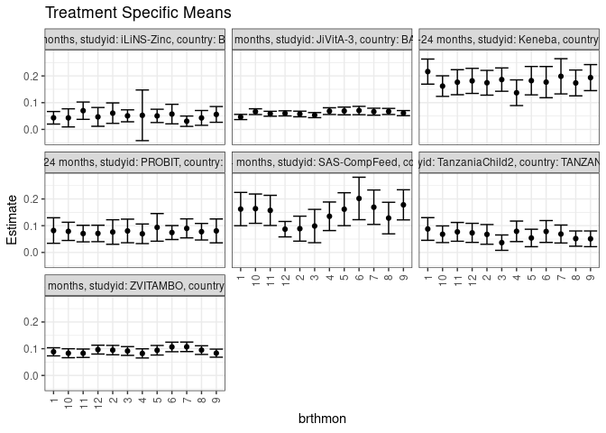

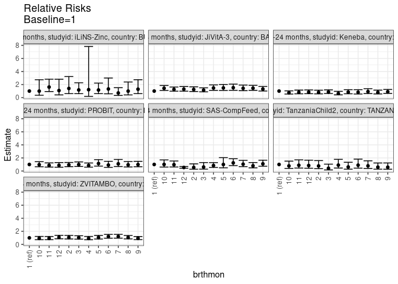

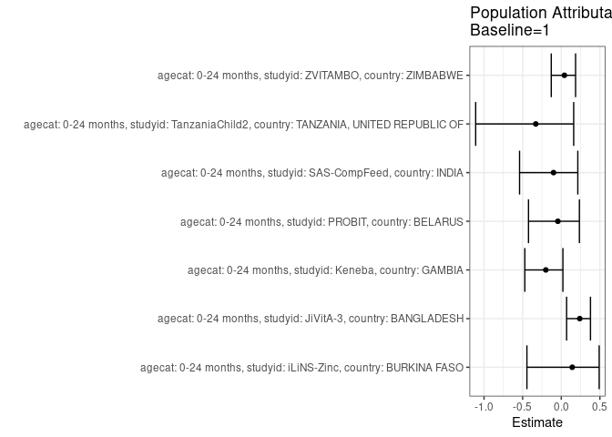

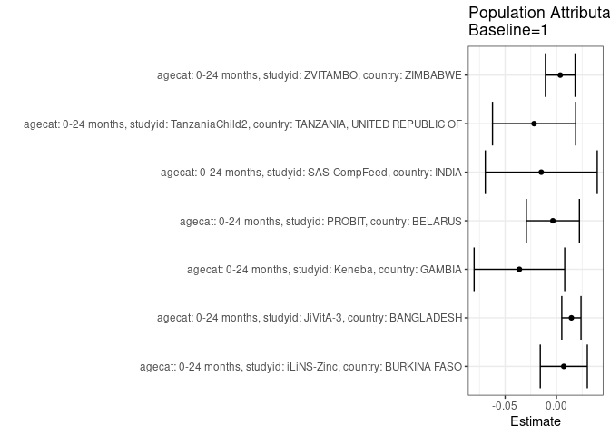

## Results Table

### Parameter: TSM

| agecat | studyid | country | intervention_level | baseline_level | estimate | ci_lower | ci_upper |
| --- | --- | --- | --- | --- | --- | --- | --- |
| 0-24 months | iLiNS-Zinc | BURKINA FASO | 1 | NA | 0.0433437 | 0.0198991 | 0.0667882 |
| 0-24 months | iLiNS-Zinc | BURKINA FASO | 2 | NA | 0.0607735 | 0.0224422 | 0.0991048 |
| 0-24 months | iLiNS-Zinc | BURKINA FASO | 3 | NA | 0.0507614 | 0.0284726 | 0.0730503 |
| 0-24 months | iLiNS-Zinc | BURKINA FASO | 4 | NA | 0.0526316 | -0.0420863 | 0.1473495 |
| 0-24 months | iLiNS-Zinc | BURKINA FASO | 5 | NA | 0.0504587 | 0.0256286 | 0.0752888 |
| 0-24 months | iLiNS-Zinc | BURKINA FASO | 6 | NA | 0.0572917 | 0.0207105 | 0.0938728 |
| 0-24 months | iLiNS-Zinc | BURKINA FASO | 7 | NA | 0.0306122 | 0.0112769 | 0.0499476 |
| 0-24 months | iLiNS-Zinc | BURKINA FASO | 8 | NA | 0.0429043 | 0.0152235 | 0.0705851 |
| 0-24 months | iLiNS-Zinc | BURKINA FASO | 9 | NA | 0.0559611 | 0.0264954 | 0.0854267 |
| 0-24 months | iLiNS-Zinc | BURKINA FASO | 10 | NA | 0.0430108 | 0.0091555 | 0.0768660 |
| 0-24 months | iLiNS-Zinc | BURKINA FASO | 11 | NA | 0.0699708 | 0.0375841 | 0.1023576 |
| 0-24 months | iLiNS-Zinc | BURKINA FASO | 12 | NA | 0.0467290 | 0.0115597 | 0.0818982 |
| 0-24 months | JiVitA-3 | BANGLADESH | 1 | NA | 0.0464371 | 0.0365988 | 0.0562755 |
| 0-24 months | JiVitA-3 | BANGLADESH | 2 | NA | 0.0576453 | 0.0471384 | 0.0681523 |
| 0-24 months | JiVitA-3 | BANGLADESH | 3 | NA | 0.0533940 | 0.0438940 | 0.0628941 |
| 0-24 months | JiVitA-3 | BANGLADESH | 4 | NA | 0.0682844 | 0.0557362 | 0.0808326 |
| 0-24 months | JiVitA-3 | BANGLADESH | 5 | NA | 0.0689394 | 0.0545056 | 0.0833732 |
| 0-24 months | JiVitA-3 | BANGLADESH | 6 | NA | 0.0705544 | 0.0549151 | 0.0861936 |
| 0-24 months | JiVitA-3 | BANGLADESH | 7 | NA | 0.0661954 | 0.0531844 | 0.0792063 |
| 0-24 months | JiVitA-3 | BANGLADESH | 8 | NA | 0.0671677 | 0.0558491 | 0.0784863 |
| 0-24 months | JiVitA-3 | BANGLADESH | 9 | NA | 0.0608570 | 0.0512338 | 0.0704803 |
| 0-24 months | JiVitA-3 | BANGLADESH | 10 | NA | 0.0663040 | 0.0555781 | 0.0770298 |
| 0-24 months | JiVitA-3 | BANGLADESH | 11 | NA | 0.0585301 | 0.0493823 | 0.0676779 |
| 0-24 months | JiVitA-3 | BANGLADESH | 12 | NA | 0.0599227 | 0.0503409 | 0.0695044 |
| 0-24 months | Keneba | GAMBIA | 1 | NA | 0.2162162 | 0.1693112 | 0.2631212 |
| 0-24 months | Keneba | GAMBIA | 2 | NA | 0.1744186 | 0.1281071 | 0.2207301 |
| 0-24 months | Keneba | GAMBIA | 3 | NA | 0.1862745 | 0.1426453 | 0.2299037 |
| 0-24 months | Keneba | GAMBIA | 4 | NA | 0.1370558 | 0.0890240 | 0.1850877 |
| 0-24 months | Keneba | GAMBIA | 5 | NA | 0.1822660 | 0.1291490 | 0.2353830 |
| 0-24 months | Keneba | GAMBIA | 6 | NA | 0.1768293 | 0.1184280 | 0.2352306 |

[output cut: 54 more lines]

### Parameter: E(Y)

| agecat | studyid | country | intervention_level | baseline_level | estimate | ci_lower | ci_upper |
| --- | --- | --- | --- | --- | --- | --- | --- |
| 0-24 months | iLiNS-Zinc | BURKINA FASO | NA | NA | 0.0505205 | 0.0383088 | 0.0627322 |
| 0-24 months | JiVitA-3 | BANGLADESH | NA | NA | 0.0610254 | 0.0575469 | 0.0645038 |
| 0-24 months | Keneba | GAMBIA | NA | NA | 0.1801370 | 0.1661957 | 0.1940783 |
| 0-24 months | PROBIT | BELARUS | NA | NA | 0.0784116 | 0.0458146 | 0.1110087 |
| 0-24 months | SAS-CompFeed | INDIA | NA | NA | 0.1473893 | 0.1184132 | 0.1763654 |
| 0-24 months | TanzaniaChild2 | TANZANIA, UNITED REPUBLIC OF | NA | NA | 0.0659432 | 0.0560037 | 0.0758828 |
| 0-24 months | ZVITAMBO | ZIMBABWE | NA | NA | 0.0922128 | 0.0874108 | 0.0970149 |

### Parameter: RR

| agecat | studyid | country | intervention_level | baseline_level | estimate | ci_lower | ci_upper |
| --- | --- | --- | --- | --- | --- | --- | --- |
| 0-24 months | iLiNS-Zinc | BURKINA FASO | 1 | 1 | 1.0000000 | 1.0000000 | 1.0000000 |
| 0-24 months | iLiNS-Zinc | BURKINA FASO | 2 | 1 | 1.4021310 | 0.6098925 | 3.2234720 |
| 0-24 months | iLiNS-Zinc | BURKINA FASO | 3 | 1 | 1.1711385 | 0.6044760 | 2.2690155 |
| 0-24 months | iLiNS-Zinc | BURKINA FASO | 4 | 1 | 1.2142857 | 0.1884255 | 7.8253207 |
| 0-24 months | iLiNS-Zinc | BURKINA FASO | 5 | 1 | 1.1641547 | 0.6105681 | 2.2196641 |
| 0-24 months | iLiNS-Zinc | BURKINA FASO | 6 | 1 | 1.3218006 | 0.5830174 | 2.9967488 |
| 0-24 months | iLiNS-Zinc | BURKINA FASO | 7 | 1 | 0.7062682 | 0.3287114 | 1.5174854 |
| 0-24 months | iLiNS-Zinc | BURKINA FASO | 8 | 1 | 0.9898633 | 0.4100658 | 2.3894440 |
| 0-24 months | iLiNS-Zinc | BURKINA FASO | 9 | 1 | 1.2911018 | 0.6091635 | 2.7364478 |
| 0-24 months | iLiNS-Zinc | BURKINA FASO | 10 | 1 | 0.9923195 | 0.3601550 | 2.7340954 |
| 0-24 months | iLiNS-Zinc | BURKINA FASO | 11 | 1 | 1.6143274 | 0.9266839 | 2.8122349 |
| 0-24 months | iLiNS-Zinc | BURKINA FASO | 12 | 1 | 1.0781041 | 0.4136187 | 2.8100963 |
| 0-24 months | JiVitA-3 | BANGLADESH | 1 | 1 | 1.0000000 | 1.0000000 | 1.0000000 |
| 0-24 months | JiVitA-3 | BANGLADESH | 2 | 1 | 1.2413625 | 0.9334046 | 1.6509248 |
| 0-24 months | JiVitA-3 | BANGLADESH | 3 | 1 | 1.1498130 | 0.8821344 | 1.4987171 |
| 0-24 months | JiVitA-3 | BANGLADESH | 4 | 1 | 1.4704698 | 1.1116734 | 1.9450688 |
| 0-24 months | JiVitA-3 | BANGLADESH | 5 | 1 | 1.4845742 | 1.0967696 | 2.0095019 |
| 0-24 months | JiVitA-3 | BANGLADESH | 6 | 1 | 1.5193516 | 1.1176165 | 2.0654931 |
| 0-24 months | JiVitA-3 | BANGLADESH | 7 | 1 | 1.4254831 | 1.0596199 | 1.9176708 |
| 0-24 months | JiVitA-3 | BANGLADESH | 8 | 1 | 1.4464213 | 1.1144384 | 1.8772996 |
| 0-24 months | JiVitA-3 | BANGLADESH | 9 | 1 | 1.3105249 | 1.0091300 | 1.7019368 |
| 0-24 months | JiVitA-3 | BANGLADESH | 10 | 1 | 1.4278219 | 1.0984528 | 1.8559517 |
| 0-24 months | JiVitA-3 | BANGLADESH | 11 | 1 | 1.2604154 | 0.9826912 | 1.6166287 |
| 0-24 months | JiVitA-3 | BANGLADESH | 12 | 1 | 1.2904039 | 0.9832016 | 1.6935919 |
| 0-24 months | Keneba | GAMBIA | 1 | 1 | 1.0000000 | 1.0000000 | 1.0000000 |
| 0-24 months | Keneba | GAMBIA | 2 | 1 | 0.8066860 | 0.5725283 | 1.1366118 |
| 0-24 months | Keneba | GAMBIA | 3 | 1 | 0.8615196 | 0.6260615 | 1.1855321 |
| 0-24 months | Keneba | GAMBIA | 4 | 1 | 0.6338832 | 0.4197672 | 0.9572162 |
| 0-24 months | Keneba | GAMBIA | 5 | 1 | 0.8429803 | 0.5861874 | 1.2122673 |
| 0-24 months | Keneba | GAMBIA | 6 | 1 | 0.8178354 | 0.5508799 | 1.2141569 |

[output cut: 54 more lines]

### Parameter: PAR

| agecat | studyid | country | intervention_level | baseline_level | estimate | ci_lower | ci_upper |
| --- | --- | --- | --- | --- | --- | --- | --- |
| 0-24 months | iLiNS-Zinc | BURKINA FASO | 1 | NA | 0.0071769 | -0.0157387 | 0.0300924 |
| 0-24 months | JiVitA-3 | BANGLADESH | 1 | NA | 0.0145882 | 0.0052183 | 0.0239581 |
| 0-24 months | Keneba | GAMBIA | 1 | NA | -0.0360792 | -0.0802198 | 0.0080614 |
| 0-24 months | PROBIT | BELARUS | 1 | NA | -0.0034597 | -0.0293134 | 0.0223940 |
| 0-24 months | SAS-CompFeed | INDIA | 1 | NA | -0.0147729 | -0.0692896 | 0.0397439 |
| 0-24 months | TanzaniaChild2 | TANZANIA, UNITED REPUBLIC OF | 1 | NA | -0.0217761 | -0.0622799 | 0.0187278 |
| 0-24 months | ZVITAMBO | ZIMBABWE | 1 | NA | 0.0037370 | -0.0107192 | 0.0181932 |

### Parameter: PAF

| agecat | studyid | country | intervention_level | baseline_level | estimate | ci_lower | ci_upper |
| --- | --- | --- | --- | --- | --- | --- | --- |
| 0-24 months | iLiNS-Zinc | BURKINA FASO | 1 | NA | 0.1420584 | -0.4448819 | 0.4905716 |
| 0-24 months | JiVitA-3 | BANGLADESH | 1 | NA | 0.2390518 | 0.0689769 | 0.3780582 |
| 0-24 months | Keneba | GAMBIA | 1 | NA | -0.2002877 | -0.4718476 | 0.0211686 |
| 0-24 months | PROBIT | BELARUS | 1 | NA | -0.0441223 | -0.4242614 | 0.2345567 |
| 0-24 months | SAS-CompFeed | INDIA | 1 | NA | -0.1002303 | -0.5400317 | 0.2139729 |
| 0-24 months | TanzaniaChild2 | TANZANIA, UNITED REPUBLIC OF | 1 | NA | -0.3302243 | -1.1082504 | 0.1606800 |
| 0-24 months | ZVITAMBO | ZIMBABWE | 1 | NA | 0.0405256 | -0.1297655 | 0.1851486 |